# final-project

Adriel Orozco

5/16/2018

**Introduction:**

Videogames are a huge market, according to fortune.com the total revenues for the industry were $23.5 billion in 2015 in the US alone. In this tutorial, I will show how to collect data on video game sales and then tidy it. After that, we will do some exploratory analysis on the data, in order to come up with possible hypotheses about the data. Then I will show how to test these hypotheses using Machine Learning.

**1. Starting**

To start off, download the CSV file from https://www.kaggle.com/rush4ratio/video-game-sales-with-ratings. This file is in CSV format. You then read the CSV into an R dataframe. The data has these fields: Name (Name of videogame), Platform (Platform game is sold on (PS4/Wii/etc.)), Year_Of_Release (year game was initially released), Genre (type of game (action,sports, role-playing,etc.)), Publisher (who published the game (Ninentdo, Microsoft, etc.)), NA_Sales (number of copies sold in North America),EU_Sales (number of copies sold in the European Union), JP_Sales (number of copies sold in Japan), Other_Sales (number of copies sold everywhere else), Global_Sales (total sales of game), Critic_Score (aggregate score of game taken from Metacritic.com from professional critics), Critic_Count (how many scores were taken to make up the aggregate score), User_Score (aggregate score of game taken from metacritic.com from reviewers on the site), User_Count (Number of users who gave a user_score), Developer (party responsible for creating the game), and Rating (ESRB rating of game (E,T,M,etc.))

```r
library(tidyverse)
```

```r
library(ISLR)
library(dplyr)
library(broom)
library(ggplot2)
#loading data from csv
videoGameData <- read.csv("Video_Games_Sales_as_at_22_Dec_2016.csv")
videoGameData %>% head() %>%
  as_data_frame()
```

```
## # A tibble: 6 x 16
##   Name        Platform Year_of_Release Genre   Publisher NA_Sales EU_Sales
## * <fct>       <fct>    <fct>           <fct>   <fct>        <dbl>    <dbl>
## 1 Wii Sports  Wii      2006            Sports  Nintendo      41.4    29.0
## 2 Super Mari… NES      1985            Platfo… Nintendo      29.1     3.58
## 3 Mario Kart… Wii      2008            Racing  Nintendo      15.7    12.8
## 4 Wii Sports… Wii      2009            Sports  Nintendo      15.6    10.9
## 5 Pokemon Re… GB       1996            Role-P… Nintendo      11.3     8.89
## 6 Tetris      GB       1989            Puzzle  Nintendo      23.2     2.26
## # ... with 9 more variables: JP_Sales <dbl>, Other_Sales <dbl>,
## #   Global_Sales <dbl>, Critic_Score <int>, Critic_Count <int>,
## #   User_Score <fct>, User_Count <int>, Developer <fct>, Rating <fct>
```

**2.Tidying Data**

```r
#User_Score saved as a factor, converting it to double, then multiplying that by 10 so its the same format as the Critic_Score column. Also multiplied each of the sales numbers by 1 million, as the previous values were in thousands
videoGameData$User_Score <- as.numeric(as.character(videoGameData$User_Score))
videoGameData$Year_of_Release <- as.integer(as.character(videoGameData$Year_of_Release))
videoGameData$User_Score <- videoGameData$User_Score * 10.0
videoGameData$User_Score <- as.integer(videoGameData$User_Score)
videoGameData$NA_Sales <- videoGameData$NA_Sales * 1000000
videoGameData$NA_Sales <- as.integer(videoGameData$NA_Sales)
videoGameData$EU_Sales <- videoGameData$EU_Sales * 1000000
videoGameData$EU_Sales <- as.integer(videoGameData$EU_Sales)
videoGameData$JP_Sales <- videoGameData$JP_Sales * 1000000
videoGameData$JP_Sales <- as.integer(videoGameData$JP_Sales)
videoGameData$Other_Sales <- videoGameData$Other_Sales * 1000000
videoGameData$Other_Sales <- as.integer(videoGameData$Other_Sales)
videoGameData$Global_Sales <- videoGameData$Global_Sales * 1000000
videoGameData$Global_Sales <- as.integer(videoGameData$Global_Sales)
videoGameData$Rating[videoGameData$Rating == ""] <- NA
videoGameData$Developer[videoGameData$Developer == ""] <- NA
#filtering data before 2016, as some values were N/A, or non-valid dates
videoGameData <- videoGameData%>%
  filter(Year_of_Release <= 2016)

videoGameData %>% head()
```

```
##                       Name Platform Year_of_Release        Genre Publisher
## 1               Wii Sports      Wii            2006       Sports  Nintendo
## 2        Super Mario Bros.      NES            1985     Platform  Nintendo
## 3           Mario Kart Wii      Wii            2008       Racing  Nintendo
## 4        Wii Sports Resort      Wii            2009       Sports  Nintendo
## 5 Pokemon Red/Pokemon Blue       GB            1996 Role-Playing  Nintendo
## 6                   Tetris       GB            1989       Puzzle  Nintendo
##   NA_Sales EU_Sales JP_Sales Other_Sales Global_Sales Critic_Score
## 1 41360000 28960000  3770000     8450000     82530000           76
## 2 29080000  3580000  6810000      770000     40240000           NA
## 3 15680000 12760000  3790000     3290000     35520000           82
## 4 15610000 10930000  3280000     2950000     32770000           80
## 5 11270000  8890000 10220000     1000000     31370000           NA
## 6 23200000  2260000  4220000      580000     30260000           NA
##   Critic_Count User_Score User_Count Developer Rating
## 1           51         80        322  Nintendo      E
## 2           NA         NA         NA      <NA>   <NA>
## 3           73         83        709  Nintendo      E
## 4           73         80        192  Nintendo      E
## 5           NA         NA         NA      <NA>   <NA>
## 6           NA         NA         NA      <NA>   <NA>
```

**3.Exploration**

```r
total_sales_df <- videoGameData %>%
  group_by(Year_of_Release) %>%
  summarize(sum(Global_Sales))
total_sales_df
```

```
## # A tibble: 37 x 2
##    Year_of_Release `sum(Global_Sales)`
##              <int>               <int>
##  1            1980            11380000
##  2            1981            35770000
##  3            1982            28860000
##  4            1983            16790000
##  5            1984            50360000
##  6            1985            53940000
##  7            1986            37070000
##  8            1987            21740000
##  9            1988            47220000
## 10            1989            73450000
## # ... with 27 more rows
```

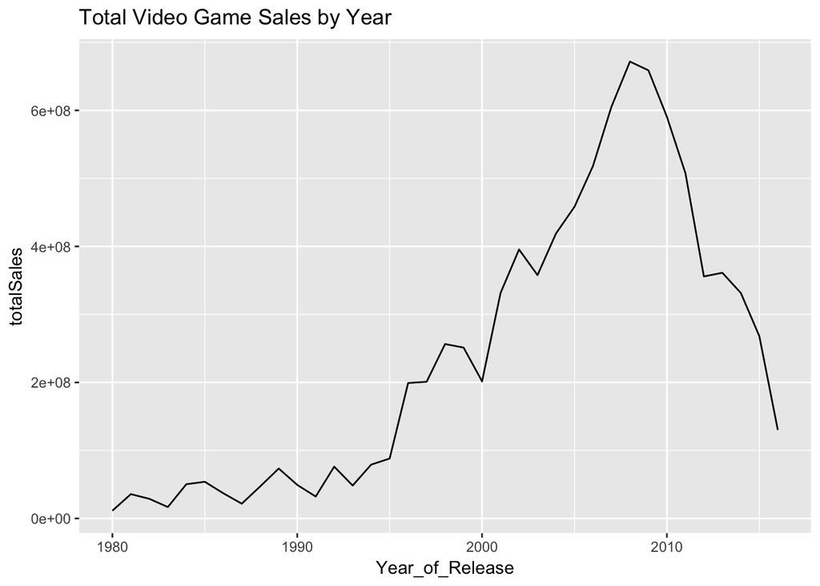

```r
total_sales_df$totalSales = total_sales_df$`sum(Global_Sales)`

total_sales_df <-
  total_sales_df %>% dplyr::select(Year_of_Release,totalSales)

total_sales_df %>%
  ggplot(mapping=aes(x=Year_of_Release,y=totalSales)) +
  ggtitle("Total Video Game Sales by Year") +
  geom_line()
```

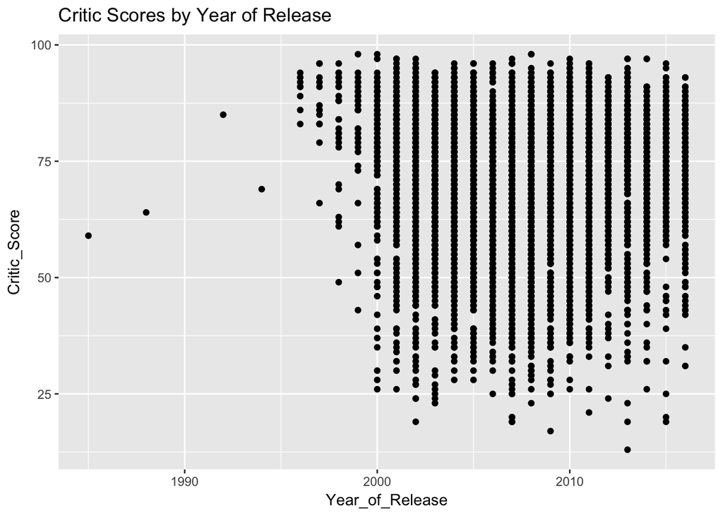

```r
videoGameData %>%
  filter(!is.na(Critic_Score)) %>%
  filter(!is.na(User_Score)) %>%
  filter(Year_of_Release > 1995 && Year_of_Release <= 2016) %>%
  ggplot(aes(x=Year_of_Release,y=Critic_Score)) + geom_point() +
  ggtitle("Critic Scores by Year of Release")
```

The number of new games being released starting in 2012 took a noticeably big dip, being almost halved from the previous year. It has since stayed fairly consistent. Visually, the two graphs (Total Video Game Sales by Year) and (Number of New Games Released Each Year) are very similar. Indicating that the more video games created, the more sales.

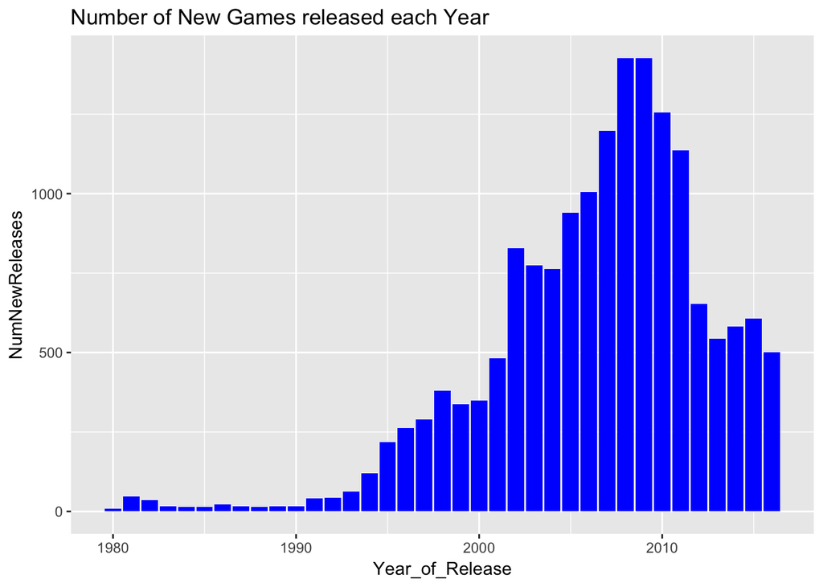

```r
num_new_releases <- videoGameData %>%
  group_by(Year_of_Release) %>%
  count()

num_new_releases$NumNewReleases <- num_new_releases$n
num_new_releases %>%
  ggplot(mapping=aes(x=Year_of_Release,y=NumNewReleases)) +
  ggtitle("Number of New Games released each Year") +
  geom_col(fill="blue")
```

This graph looks at the Total Sales by each Region (NA,JP,EU, and Other) for each year. Overall it seems that NA is the region with the most sales, followed by the EU. Then, JP and Other are at the bottom, being fairly close to each other.

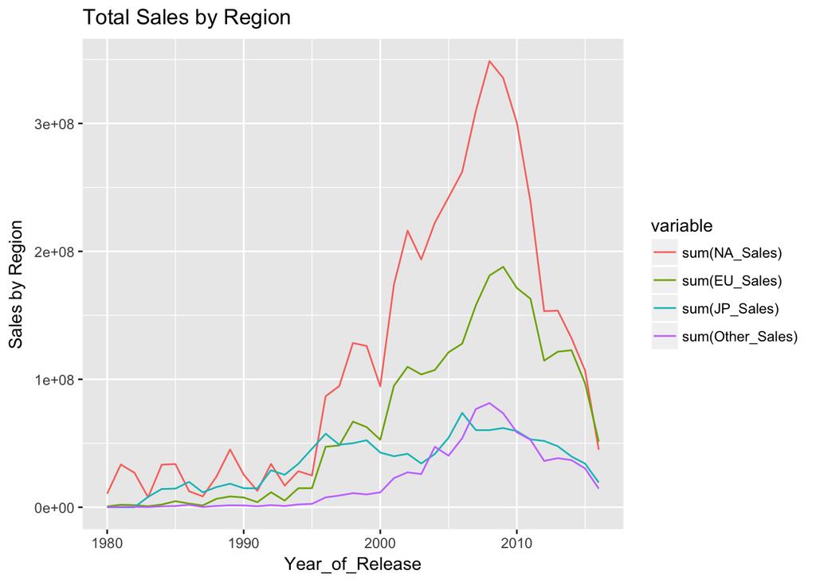

```r
sales_by_region <- videoGameData %>%
  group_by(Year_of_Release) %>%
  summarize(sum(NA_Sales),sum(EU_Sales),sum(JP_Sales),sum(Other_Sales))

region_sales_long <- reshape2::melt(sales_by_region,id="Year_of_Release",measure= c("sum(NA_Sales)","sum(EU_Sales)","sum(JP_Sales)","sum(Other_Sales)"))

ggplot(region_sales_long,aes(Year_of_Release,value,colour=variable))+
         geom_line() +
          ylab("Sales by Region") +
         ggtitle("Total Sales by Region")
```

Next, I wanted to see which genre of games overall has the best sales. We have found that Action and Sports games are the overall best sellers.

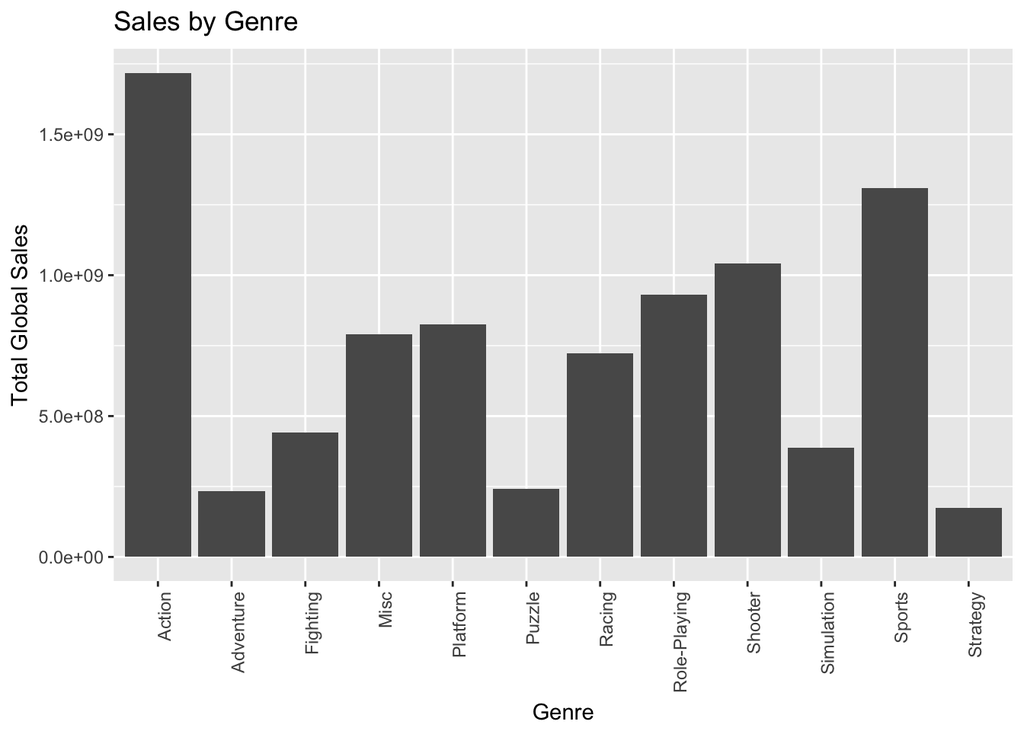

```r
sales_by_genre <- videoGameData %>%
  group_by(Genre) %>%
   summarize(sum(Global_Sales)) %>%
  filter(!Genre == "")


sales_by_genre %>%
  ggplot(mapping = aes(x=Genre,y=`sum(Global_Sales)`)) +
  ggtitle("Sales by Genre") +
  geom_col() +
    ylab("Total Global Sales") +
    theme( axis.text.x = element_text(angle=90, hjust=1))
```

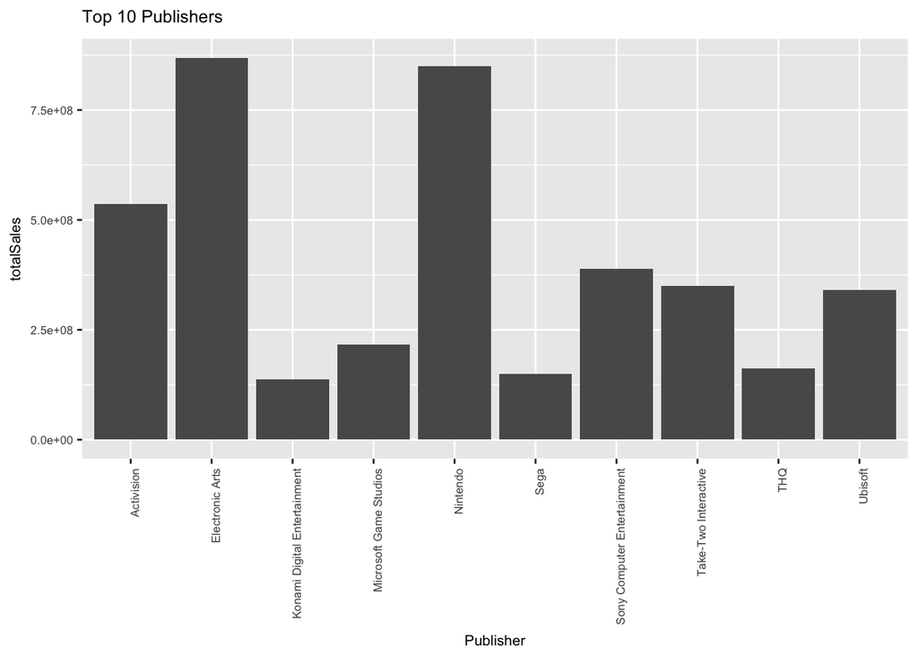

```r
top_publishers <- videoGameData %>%
  filter(!is.na(Critic_Score)) %>%
  filter(!is.na(User_Score)) %>%
  group_by(Publisher) %>%
  summarize(sum(Global_Sales))

top_publishers$totalSales = top_publishers$`sum(Global_Sales)`
top_publishers <- top_publishers %>%
  dplyr::select(totalSales,Publisher) %>%
  arrange(desc(totalSales)) %>%
  slice(1:10)


top_publishers %>%
  ggplot(mapping=aes(x=Publisher,y=totalSales)) +
  geom_col()  +
    theme( text = element_text(size=8),axis.text.x = element_text(angle=90, hjust=1)) +
  ggtitle("Top 10 Publishers")
```

**4.Hypothesis Testing and ML**

```r
mean_sales <- mean(videoGameData$Global_Sales)
greater_than_mean <- videoGameData %>%
                  mutate(isSuccessful = ifelse(videoGameData$Global_Sales > mean_sales,TRUE,FALSE)) %>%
  dplyr::select(Name,Critic_Score,User_Score,isSuccessful,Global_Sales,NA_Sales,EU_Sales,JP_Sales,Other_Sales,Platform) %>%
  filter(!is.na(Critic_Score)) %>%
 filter(!is.na(User_Score))
greater_than_mean %>%head()
```

```
##                        Name Critic_Score User_Score isSuccessful
## 1                Wii Sports           76         80         TRUE
## 2            Mario Kart Wii           82         83         TRUE
## 3         Wii Sports Resort           80         80         TRUE
## 4     New Super Mario Bros.           89         85         TRUE
## 5                  Wii Play           58         66         TRUE
## 6 New Super Mario Bros. Wii           87         84         TRUE
##   Global_Sales NA_Sales EU_Sales JP_Sales Other_Sales Platform
## 1     82530000 41360000 28960000  3770000     8450000      Wii
## 2     35520000 15680000 12760000  3790000     3290000      Wii
## 3     32770000 15610000 10930000  3280000     2950000      Wii
## 4     29800000 11280000  9140000  6500000     2880000       DS
## 5     28920000 13960000  9180000  2930000     2840000      Wii
## 6     28320000 14440000  6940000  4700000     2240000      Wii
```

```r
default_fit <- glm(isSuccessful ~ Critic_Score , data=greater_than_mean, family=binomial)
default_fit %>%
  broom::tidy()
```

```
##           term    estimate std.error statistic       p.value
## 1  (Intercept) -5.63656070 0.1900228 -29.66255 2.336216e-193
## 2 Critic_Score  0.06827345 0.0025283  27.00370 1.337286e-160
```

To check how good our classifiers are doing, we compute the error rate for the classifiers. As can be seen below, the model is fairly good at predicting false data (False/False). But is not particularly good at predicting (True,True) data.

```r
lda_fit <- MASS::lda(isSuccessful ~ Critic_Score , data=greater_than_mean)
lda_pred <- predict(lda_fit, data=greater_than_mean)
print(table(predicted=lda_pred$class, observed=greater_than_mean$isSuccessful))
```

```
##          observed
## predicted FALSE TRUE
##     FALSE  4220 1571
##     TRUE    370  733
```

```r
#error rate
mean(greater_than_mean$isSuccessful != lda_pred$class) * 100
```

```
## [1] 28.15492
```

```r
# dummy error rate
mean(greater_than_mean$isSuccessful!= FALSE) * 100
```

```
## [1] 33.42037
```

This creates a new dataframe that we will use in our next logistic regression model. This creates a new column which checks if the Publisher of a game is considered a “top publisher”. A top publisher is defined as top 10 publishers in game copies sold.

```r
is_top_publisher <- videoGameData %>%
   mutate(isSuccessful = ifelse(videoGameData$Global_Sales > mean_sales,TRUE,FALSE)) %>%
  mutate(isTopPublisher = ifelse(is.element(videoGameData$Publisher,top_publishers$Publisher),TRUE,FALSE)) %>%
 filter(!is.na(Critic_Score)) %>%
 filter(!is.na(User_Score)) %>%
  dplyr::select(Name,Publisher,Global_Sales,isTopPublisher,isSuccessful,Critic_Score,User_Score)
```

```r
fit_is_top <- glm(isSuccessful~Critic_Score + User_Score + isTopPublisher,data=is_top_publisher,family=binomial)
fit_is_top %>%
  broom::tidy()
```

```
##                 term     estimate   std.error  statistic       p.value
## 1        (Intercept) -5.540606654 0.208181907 -26.614256 4.642752e-156
## 2       Critic_Score  0.068212036 0.002929651  23.283328 6.541514e-120
## 3         User_Score -0.008191025 0.002500783  -3.275384  1.055186e-03
## 4 isTopPublisherTRUE  0.852303124 0.058307873  14.617291  2.179009e-48
```

```r
lda_fit <- MASS::lda(isSuccessful~Critic_Score + User_Score + isTopPublisher ,data=is_top_publisher)
lda_pred <- predict(lda_fit, data=is_top_publisher)
print(table(predicted=lda_pred$class, observed=is_top_publisher$isSuccessful))
```

```
##          observed
## predicted FALSE TRUE
##     FALSE  4008 1310
##     TRUE    582  994
```

```r
#error rate
mean(is_top_publisher$isSuccessful!= lda_pred$class) * 100
```

```
## [1] 27.44415
```

```r
# dummy error rate
mean(is_top_publisher$isSuccessful!= FALSE) * 100
```

```
## [1] 33.42037
```

**5.Conclusion**

Overall, we were not able to find a good logistic regression model that fit in with my hypotheses. I can see a few reasons as to why this is. First off, almost all of the highest selling games are games that come with the Platform that you can play them on. As a result, there are many well selling games that simply come with the Platform when you purchase it, so people do not actively choose to purchase many of these popular games. Another important reason is that the source of the data: VGChartz (as stated in the kaggle link) can be unreliable, especially in recent years. This is due to data from VGChartz only counting the physical copies sold for games, when in recent years the majority of sales are often online sales. As a result of this, much of the more “recent” data (from Platforms such as PS3/PS4/XBOX360/XBOX ONE/WII/etc. which allow you to purchase games online, from 2006 and onward) can be considered inaccurate as it is missing a very sizable portion of the data from 2006 onwards. This is especially important as in one of my previous graphs, it is shown that more than half the data is from after 2006.